# Biostat 212a Homework 2

Due Feb 8, 2025 @ 11:59PM

Author

Nathaniel Boyle and 006525153

Published

February 6, 2025

## 1 ISL Exercise 4.8.1 (10pts)

Using a little bit of algebra, prove that (4.2) is equivalent to (4.3). In other words, the logistic function representation and logit representation for the logistic regression model are equivalent.

$$p(X) = \frac{e^{\beta_0 + \beta_1 X}}{1 + e^{\beta_0 + \beta_1 X}}$$

$$\frac{p(X)} {1 − p(X)} = eβ_0+β_1X$$
We have $p(X) = \frac{e^{\beta_0 + \beta_1 X}}{1 + e^{\beta_0 + \beta_1 X}}$ by definition Thus,
$$1-p(X)= 1- \frac{e^{\beta_0 + \beta_1 X}}{1 + e^{\beta_0 + \beta_1 X}}$$
Simplify with common denominator

$$1- \frac{e^{\beta_0 + \beta_1 X}}{1 + e^{\beta_0 + \beta_1 X}} = \frac{1 + e^{\beta_0 + \beta_1 X}-e^{\beta_0 + \beta_1 X}}{1 + e^{\beta_0 + \beta_1 X}} = \frac{1}{1 + e^{\beta_0 + \beta_1 X}} = 1-p(X)$$
Therefore,
$$\frac{p(X)}{1-p(X)} = \frac{(1 + e^{\beta_0 + \beta_1 X})e^{\beta_0 + \beta_1 X}}{1 + e^{\beta_0 + \beta_1 X}}=e^{\beta_0 + \beta_1 X}$$
## ISL Exercise 4.8.6 (10pts) Suppose we collect data for a group of students in a statistics class with variables $X_1 = hours$ studied, $X_2 = undergrad GPA$, and Y =receive an A. We ft a logistic regression and produce estimated coefficient, $\hatβ_0 = −6$, $\hatβ_1 = 0.05$, $\hatβ_2 = 1$.

Estimate the probability that a student who studies for 40 h and has an undergrad GPA of 3.5 gets an A in the class

From our logistic regression model we plug in our values to obtain a logit value:
$$logit(p) = \hatβ_0 + \hatβ_1X_1 +\hatβ_2X_2 = −6 + 0.05(40) + 1(3.5) = -0.5$$
Now we convert this logit value to a probability:
$$p = \frac{1}{1+e^{-logit(p)}} = \frac{1}{1+e^{0.5}} ≈ 0.378$$
This means our student in this case has a roughly 37.8% chance of getting an A.

How many hours would the student in part (a) need to study to have a 50 % chance of getting an A in the class?

A 50% chance is equivalent to $logit(p)=0$ thus we can solve for X, the amount of hours we study for:

$$0 = −6 + 0.05(X) + 1(3.5)$$
$$\frac{6-3.5}{0.05} = X = 50$$
Thus a student with a GPA of 3.5 would need 50 hours of studying for a 50% chance to get an A, according to this logistic model.

## 2 ISL Exercise 4.8.9 (10pts)

This problem has to do with odds.

1. On average, what fraction of people with an odds of 0.37 of defaulting on their credit card payment will in fact default?

The odds of something occurring is expressed as a ratio of the probability that the event will occur to the probability that it will not occur

$$\frac{p}{1-p}=odds$$
Given our odds are 0.37, we can solve for p with some algebra.
$$p=0.37(1-p) = 0.37-0.37p$$
$$1.37p = 0.37$$
$$p=\frac{0.37}{1.37}≈0.27$$
Thus the fraction of people with an odds of 0.37 that default will be roughly 27% of people.

2. Suppose that an individual has a 16 % chance of defaulting on her credit card payment. What are the odds that she will default?

Here we have the probability $p=0.16$, thus we simply solve for the ratio:
$$\frac{p}{1-p} = odds = \frac{0.16}{1-0.16} ≈ 0.19$$
Thus the odds of an individual with a 16% chance of defaulting is 0.19. ## ISL Exercise 4.8.13 (a)-(i) (50pts)

This question should be answered using the Weekly data set, which is part of the ISLR2 package. This data is similar in nature to the Smarket data from this chapter’s lab, except that it contains 1, 089 weekly returns for 21 years, from the beginning of 1990 to the end of 2010.

1. Produce some numerical and graphical summaries of the Weekly data.

```r
# Load the ISLR2 package
#install.packages("ISLR2")
library(ISLR2)

#documentation
?Weekly

# Show the first few rows of the dataset
head(Weekly)
```

```
  Year   Lag1   Lag2   Lag3   Lag4   Lag5    Volume  Today Direction
1 1990  0.816  1.572 -3.936 -0.229 -3.484 0.1549760 -0.270      Down
2 1990 -0.270  0.816  1.572 -3.936 -0.229 0.1485740 -2.576      Down
3 1990 -2.576 -0.270  0.816  1.572 -3.936 0.1598375  3.514        Up
4 1990  3.514 -2.576 -0.270  0.816  1.572 0.1616300  0.712        Up
5 1990  0.712  3.514 -2.576 -0.270  0.816 0.1537280  1.178        Up
6 1990  1.178  0.712  3.514 -2.576 -0.270 0.1544440 -1.372      Down
```

```r
#print statistical summary
summary(Weekly)
```

```
      Year           Lag1               Lag2               Lag3
 Min.   :1990   Min.   :-18.1950   Min.   :-18.1950   Min.   :-18.1950
 1st Qu.:1995   1st Qu.: -1.1540   1st Qu.: -1.1540   1st Qu.: -1.1580
 Median :2000   Median :  0.2410   Median :  0.2410   Median :  0.2410
 Mean   :2000   Mean   :  0.1506   Mean   :  0.1511   Mean   :  0.1472
 3rd Qu.:2005   3rd Qu.:  1.4050   3rd Qu.:  1.4090   3rd Qu.:  1.4090
 Max.   :2010   Max.   : 12.0260   Max.   : 12.0260   Max.   : 12.0260
      Lag4               Lag5              Volume            Today
 Min.   :-18.1950   Min.   :-18.1950   Min.   :0.08747   Min.   :-18.1950
 1st Qu.: -1.1580   1st Qu.: -1.1660   1st Qu.:0.33202   1st Qu.: -1.1540
 Median :  0.2380   Median :  0.2340   Median :1.00268   Median :  0.2410
 Mean   :  0.1458   Mean   :  0.1399   Mean   :1.57462   Mean   :  0.1499
 3rd Qu.:  1.4090   3rd Qu.:  1.4050   3rd Qu.:2.05373   3rd Qu.:  1.4050
 Max.   : 12.0260   Max.   : 12.0260   Max.   :9.32821   Max.   : 12.0260
 Direction
 Down:484
 Up  :605
```

```r
#correlation matrix
cor(Weekly[, -9])  # Excluding 'Direction' because it's categorical
```

```
              Year         Lag1        Lag2        Lag3         Lag4
Year    1.00000000 -0.032289274 -0.03339001 -0.03000649 -0.031127923
Lag1   -0.03228927  1.000000000 -0.07485305  0.05863568 -0.071273876
Lag2   -0.03339001 -0.074853051  1.00000000 -0.07572091  0.058381535
Lag3   -0.03000649  0.058635682 -0.07572091  1.00000000 -0.075395865
Lag4   -0.03112792 -0.071273876  0.05838153 -0.07539587  1.000000000
Lag5   -0.03051910 -0.008183096 -0.07249948  0.06065717 -0.075675027
Volume  0.84194162 -0.064951313 -0.08551314 -0.06928771 -0.061074617
Today  -0.03245989 -0.075031842  0.05916672 -0.07124364 -0.007825873
               Lag5      Volume        Today
Year   -0.030519101  0.84194162 -0.032459894
Lag1   -0.008183096 -0.06495131 -0.075031842
Lag2   -0.072499482 -0.08551314  0.059166717
Lag3    0.060657175 -0.06928771 -0.071243639
Lag4   -0.075675027 -0.06107462 -0.007825873
Lag5    1.000000000 -0.05851741  0.011012698
Volume -0.058517414  1.00000000 -0.033077783
Today   0.011012698 -0.03307778  1.000000000
```

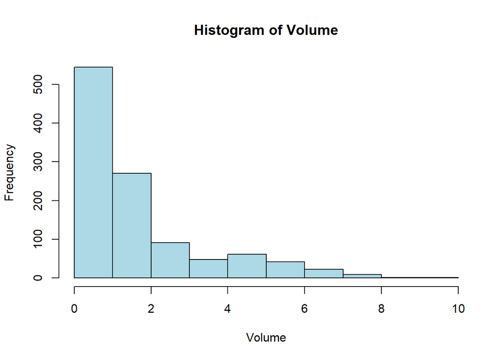

```r
#histogram of Volume
hist(Weekly$Volume, main="Histogram of Volume",
     xlab="Volume", col="lightblue", border="black")
```

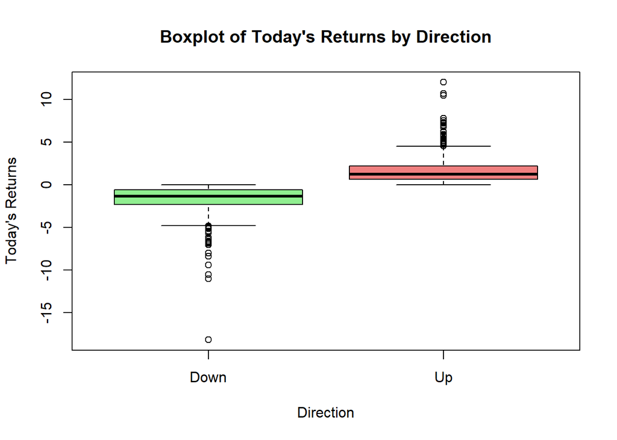

```r
# Boxplot of 'Today' returns by 'Direction' (categorical variable)
boxplot(Today ~ Direction, data=Weekly,
        main="Boxplot of Today's Returns by Direction",
        xlab="Direction",
        ylab="Today's Returns", col=c("lightgreen", "lightcoral"))
```

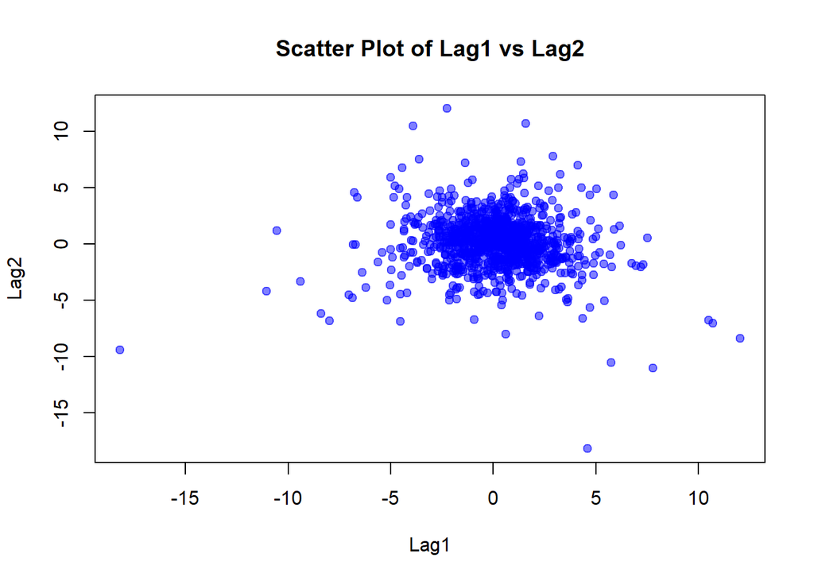

```r
# Scatter plot between 'Lag1' and 'Lag2' to check their relationship
plot(Weekly$Lag1, Weekly$Lag2, main="Scatter Plot of Lag1 vs Lag2",
     xlab="Lag1", ylab="Lag2", pch=19, col=rgb(0,0,1,0.5))
```

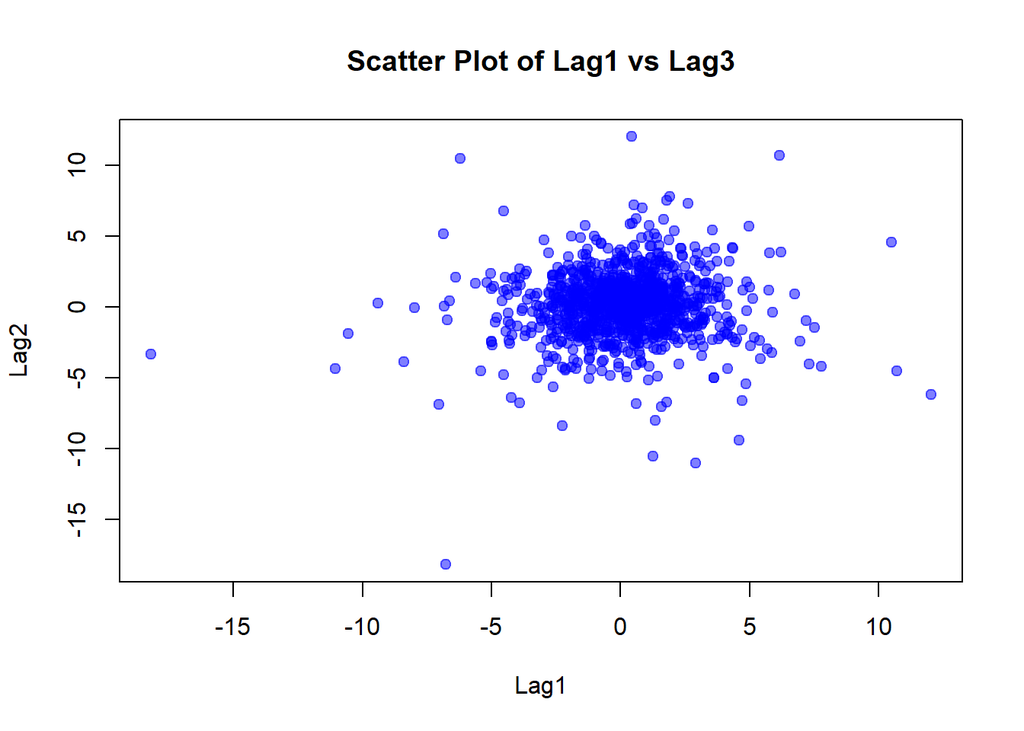

```r
#Scatter plot between 'Lag1' and 'Lag3' to check their relationship
plot(Weekly$Lag1, Weekly$Lag3, main="Scatter Plot of Lag1 vs Lag3",
     xlab="Lag1", ylab="Lag2", pch=19, col=rgb(0,0,1,0.5))
```

Do there appear to be any patterns?

From our correlation matrix, we can see that volume of trades and year is strongly correlated. This indicates seasonal changes in the market that heavily impact trades.

The lags are not very strongly correlated with much of anything in this dataset. There could still be a relationship worth exploring, but nothing from first glance suggests a strong correlation or auto-correlation.

```r
#
min_return <- min(Weekly$Today)  # Find the minimum return value

# Find the index of the row with the minimum return
min_return_index <- which(Weekly$Today == min_return)

# Get the year corresponding to the row with the minimum return
min_return_year <- Weekly$Year[min_return_index]

# Print the result
min_return_year
```

```
[1] 2008
```

The “volume” is heavily right-skewed. This means most days there was very little trading occurring, but there was a period of time when a large amount of trading suddenly occurred. This can occur during market crashes. In fact, this dataset covers the 2008 financial crisis.

```r
# Filter data for the year 2008
data_2008 <- subset(Weekly, Year == 2008)

# Summarize the data for 2008
summary(data_2008$Volume)
```

```
   Min. 1st Qu.  Median    Mean 3rd Qu.    Max.
  3.087   4.044   4.690   5.000   5.820   9.328
```

```r
summary(Weekly$Volume)
```

```
   Min. 1st Qu.  Median    Mean 3rd Qu.    Max.
0.08747 0.33202 1.00268 1.57462 2.05373 9.32821
```

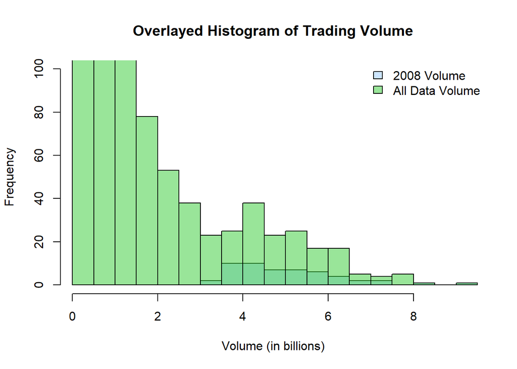

```r
# Create a histogram for the trading volume in 2008 and overlay them
# Plot the first histogram for 2008 trading volume
hist(data_2008$Volume, main = "Overlayed Histogram of Trading Volume",
     xlab = "Volume (in billions)", col = rgb(0.6, 0.8, 1, 0.5), # Light blue with transparency
     border = "black", xlim = range(c(data_2008$Volume, Weekly$Volume)), # Same x-axis limits
     ylim = c(0, 100), # Adjust the y-axis if necessary to fit both histograms
     breaks = 20)  # Control the number of bins

# Overlay the second histogram for the entire dataset trading volume
hist(Weekly$Volume, col = rgb(0.2, 0.8, 0.2, 0.5), border = "black",
     add = TRUE, breaks = 20)  # `add = TRUE` adds the histogram to the existing plot

# Add a legend to distinguish the two histograms
legend("topright", legend = c("2008 Volume", "All Data Volume"),
       fill = c(rgb(0.6, 0.8, 1, 0.5), rgb(0.2, 0.8, 0.2, 0.5)), bty = "n")
```

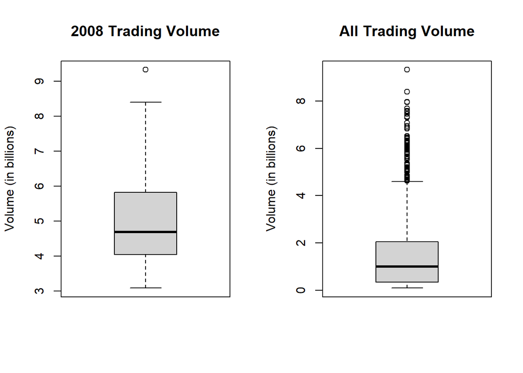

```r
# You could also look at the boxplot to identify any outlines
# Set up the plotting area to display two plots side by side
par(mfrow = c(1, 2))

# Boxplot for trading volume in 2008
boxplot(data_2008$Volume, main = "2008 Trading Volume", ylab = "Volume (in billions)")

# Boxplot for the entire dataset's trading volume
boxplot(Weekly$Volume, main = "All Trading Volume", ylab = "Volume (in billions)")
```

```r
# Reset the plotting layout to default (one plot per graph)
par(mfrow = c(1, 1))
```

Looking at the boxplots for 2008 Trading volume as well confirms that a rather unusual amount of trading occurred. This can probably be attributed to the 2008 financial crisis we discussed before.

The histogram of the volume is also confirms this higher than usual trading visually.

2. Use the full data set to perform a logistic regression with Direction as the response and the five lag variables plus Volume as predictors. Use the summary function to print the results.

```r
# Fit the logistic regression model with the five lag variables and Volume as predictors
model <- glm(Direction ~ Lag1 + Lag2 + Lag3 + Lag4 + Lag5 + Volume,
             data = Weekly,
             family = binomial)

# View the summary of the logistic regression model
summary(model)
```

```
Call:
glm(formula = Direction ~ Lag1 + Lag2 + Lag3 + Lag4 + Lag5 +
    Volume, family = binomial, data = Weekly)

Coefficients:
            Estimate Std. Error z value Pr(>|z|)
(Intercept)  0.26686    0.08593   3.106   0.0019 **
Lag1        -0.04127    0.02641  -1.563   0.1181
Lag2         0.05844    0.02686   2.175   0.0296 *
Lag3        -0.01606    0.02666  -0.602   0.5469
Lag4        -0.02779    0.02646  -1.050   0.2937
Lag5        -0.01447    0.02638  -0.549   0.5833
Volume      -0.02274    0.03690  -0.616   0.5377
---
Signif. codes:  0 '***' 0.001 '**' 0.01 '*' 0.05 '.' 0.1 ' ' 1

(Dispersion parameter for binomial family taken to be 1)

    Null deviance: 1496.2  on 1088  degrees of freedom
Residual deviance: 1486.4  on 1082  degrees of freedom
AIC: 1500.4

Number of Fisher Scoring iterations: 4
```

Do any of the predictors appear to be statistically significant? If so, which ones?

From the model lag 2 is the only significant predictor. Want to note our intercept is also significant, meaning if all other predictors are zero, the probability of our market being in the “up” direction is significantly positive.

3. Compute the confusion matrix and overall fraction of correct predictions. Explain what the confusion matrix is telling you about the types of mistakes made by logistic regression.

```r
# Generate predictions using the model
predictions <- predict(model, type = "response")
# Convert the probabilities to binary outcomes (0 = Down, 1 = Up)
predicted_class <- ifelse(predictions > 0.5, "Up", "Down")
# Create the confusion matrix
confusion_matrix <- table(Predicted = predicted_class, Actual = Weekly$Direction)
print(confusion_matrix)
```

```
         Actual
Predicted Down  Up
     Down   54  48
     Up    430 557
```

```r
# Compute overall accuracy
accuracy <- sum(diag(confusion_matrix)) / sum(confusion_matrix)
print(accuracy)
```

```
[1] 0.5610652
```

This confusion matrix is alerting us of several things. 1. The low accuracy of this model for predicting what direction the market is going to be in. 2. The over classification of up directions 3. An extension of 2. we have a large amount of “false positives” from this model (i.e. too many “up” directions are actually down.)

4. Now ft the logistic regression model using a training data period from 1990 to 2008, with Lag2 as the only predictor. Compute the confusion matrix and the overall fraction of correct predictions for the held out data (that is, the data from 2009 and 2010).

```r
# Subset the data for training (1990-2008) and testing (2009-2010)
train_data <- subset(Weekly, Year >= 1990 & Year <= 2008)
test_data <- subset(Weekly, Year >= 2009 & Year <= 2010)

# Fit the logistic regression model using Lag2 as the only predictor
model_train <- glm(Direction ~ Lag2, data = train_data, family = binomial)


# Make predictions on the test data
predictions_test <- predict(model_train, newdata = test_data, type = "response")


# Convert probabilities to predicted classes (0 = Down, 1 = Up)
predicted_class_test <- ifelse(predictions_test > 0.5, "Up", "Down")

# Create the confusion matrix
confusion_matrix_test <- table(Predicted = predicted_class_test, Actual = test_data$Direction)

# Print the confusion matrix
print(confusion_matrix_test)
```

```
         Actual
Predicted Down Up
     Down    9  5
     Up     34 56
```

```r
# Compute overall accuracy
accuracy_test <- sum(diag(confusion_matrix_test)) / sum(confusion_matrix_test)
print(paste("Overall accuracy: ", round(accuracy_test, 4)))
```

```
[1] "Overall accuracy:  0.625"
```

5. Repeat (d) using LDA.

```r
# Load the MASS package for LDA
library(MASS)

# Fit the LDA model using Lag2 as the only predictor
lda_model <- lda(Direction ~ Lag2, data = train_data)

# Make predictions on the test data
predictions_lda <- predict(lda_model, newdata = test_data)

# Extract the predicted classes
predicted_class_lda <- predictions_lda$class

# Create the confusion matrix
confusion_matrix_lda <- table(Predicted = predicted_class_lda,
                              Actual = test_data$Direction)

# Print the confusion matrix
print(confusion_matrix_lda)
```

```
         Actual
Predicted Down Up
     Down    9  5
     Up     34 56
```

```r
# Compute overall accuracy
accuracy_lda <- sum(diag(confusion_matrix_lda)) / sum(confusion_matrix_lda)
print(paste("Overall accuracy using LDA: ", round(accuracy_lda, 4)))
```

```
[1] "Overall accuracy using LDA:  0.625"
```

Notes: Linear Discriminant Analysis (LDA) Assumptions: LDA assumes that the data from both classes (“Up” and “Down”) follow a normal distribution with the same variance. Accuracy was about the same as LDA.

```r
# Fit the QDA model using Lag2 as the only predictor
qda_model <- qda(Direction ~ Lag2, data = train_data)

# Make predictions on the test data
predictions_qda <- predict(qda_model, newdata = test_data)

# Extract the predicted classes
predicted_class_qda <- predictions_qda$class

# Create the confusion matrix
confusion_matrix_qda <- table(Predicted = predicted_class_qda,
                              Actual = test_data$Direction)

# Print the confusion matrix
print(confusion_matrix_qda)
```

```
         Actual
Predicted Down Up
     Down    0  0
     Up     43 61
```

```r
# Compute overall accuracy
accuracy_qda <- sum(diag(confusion_matrix_qda)) / sum(confusion_matrix_qda)
print(paste("Overall accuracy using QDA: ", round(accuracy_qda, 4)))
```

```
[1] "Overall accuracy using QDA:  0.5865"
```

Notes: Quadratic Discriminant Analysis (QDA)

Does not assume equal covariance for the two classes in “Direction.” This can allow for more flexibility. Accuracy was lower than LDA or Logistic Regression.

6. Repeat (d) using QDA.

```r
# Fit the QDA model using Lag2 as the only predictor
qda_model <- qda(Direction ~ Lag2, data = train_data)

# Make predictions on the test data
predictions_qda <- predict(qda_model, newdata = test_data)

# Extract the predicted classes (Up/Down)
predicted_class_qda <- predictions_qda$class

# Create the confusion matrix
confusion_matrix_qda <- table(Predicted = predicted_class_qda, Actual = test_data$Direction)

# Print the confusion matrix
print(confusion_matrix_qda)
```

```
         Actual
Predicted Down Up
     Down    0  0
     Up     43 61
```

```r
# Compute overall accuracy
accuracy_qda <- sum(diag(confusion_matrix_qda)) / sum(confusion_matrix_qda)
print(paste("Overall accuracy using QDA: ", round(accuracy_qda, 4)))
```

```
[1] "Overall accuracy using QDA:  0.5865"
```

7. Repeat (d) using KNN with K = 1.

```r
# Load the class package for KNN
library(class)

# Convert the predictors into matrices
train_x <- as.matrix(train_data$Lag2)
test_x <- as.matrix(test_data$Lag2)

# Ensure the response variable is a factor (Up/Down) (We know it is but for
# learning purposes I want to leave it here so I remember to do this later)
train_y <- as.factor(train_data$Direction)
test_y <- as.factor(test_data$Direction)

# Apply KNN with K = 1
predicted_class_knn <- knn(train = train_x, test = test_x, cl = train_y, k = 1)

# Create the confusion matrix
confusion_matrix_knn <- table(Predicted = predicted_class_knn, Actual = test_y)

# Print the confusion matrix
print(confusion_matrix_knn)
```

```
         Actual
Predicted Down Up
     Down   21 29
     Up     22 32
```

```r
# Compute overall accuracy
accuracy_knn <- sum(diag(confusion_matrix_knn)) / sum(confusion_matrix_knn)
print(paste("Overall accuracy using KNN (K=1): ", round(accuracy_knn, 4)))
```

```
[1] "Overall accuracy using KNN (K=1):  0.5096"
```

8. Repeat (d) using naive Bayes.

```r
# Load the e1071 package for Naive Bayes
library(e1071)

# Lag2 is numeric, and Direction is already a factor (no need to change it)
train_x <- train_data$Lag2
test_x <- test_data$Lag2
train_y <- train_data$Direction
test_y <- test_data$Direction

# Fit the Naive Bayes model using Lag2 as the predictor
nb_model <- naiveBayes(Direction ~ Lag2, data = train_data)

# Make predictions on the test data
predictions_nb <- predict(nb_model, newdata = test_data)

# Create the confusion matrix
confusion_matrix_nb <- table(Predicted = predictions_nb, Actual = test_y)

# Print the confusion matrix
print(confusion_matrix_nb)
```

```
         Actual
Predicted Down Up
     Down    0  0
     Up     43 61
```

```r
# Compute overall accuracy
accuracy_nb <- sum(diag(confusion_matrix_nb)) / sum(confusion_matrix_nb)
print(paste("Overall accuracy using Naive Bayes: ", round(accuracy_nb, 4)))
```

```
[1] "Overall accuracy using Naive Bayes:  0.5865"
```

1. Which of these methods appears to provide the best results on this data?

The best performing model appears to be either logistic regression or LDA models. They both produced the exact same accuracy of 62.5%

## 3 Bonus question: ISL Exercise 4.8.13 Part (j) (30pts)

## 4 Bonus question: ISL Exercise 4.8.4 (30pts)